# Data Analyst Nanodegree Project 6: Exploring 5 Years of Cryptocurrency Data

### Market Share

Bitcoin has been the dominant force in the cryptocurrency world since it began.

Let’s look at how marketshare has been divided among the top coins over time.

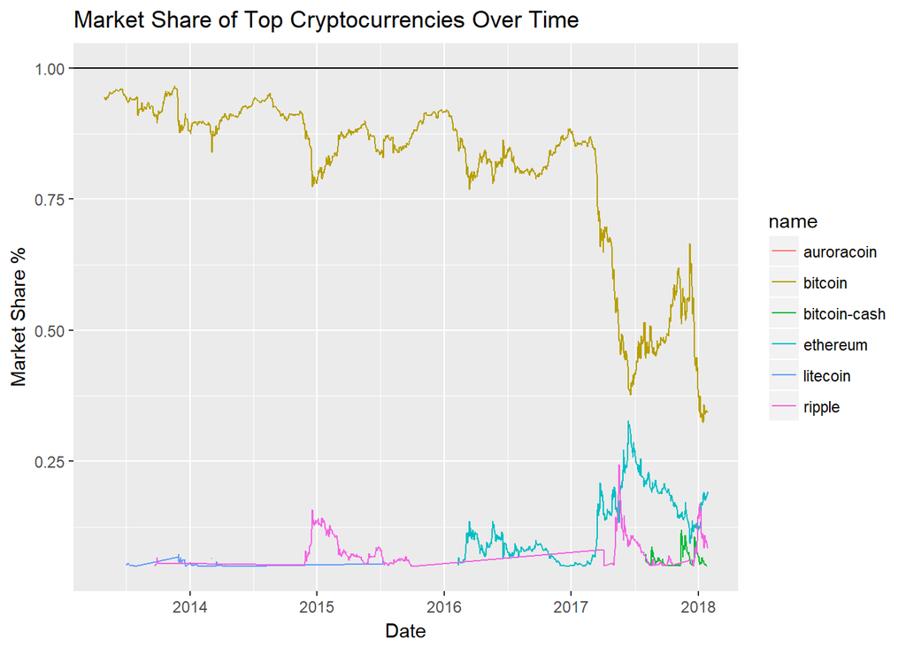

We can see that Bitcoin lost alot of marketshare in 2017 to Etheruem and Ripple. But it is still the dominant token.

But what is auroracoin?

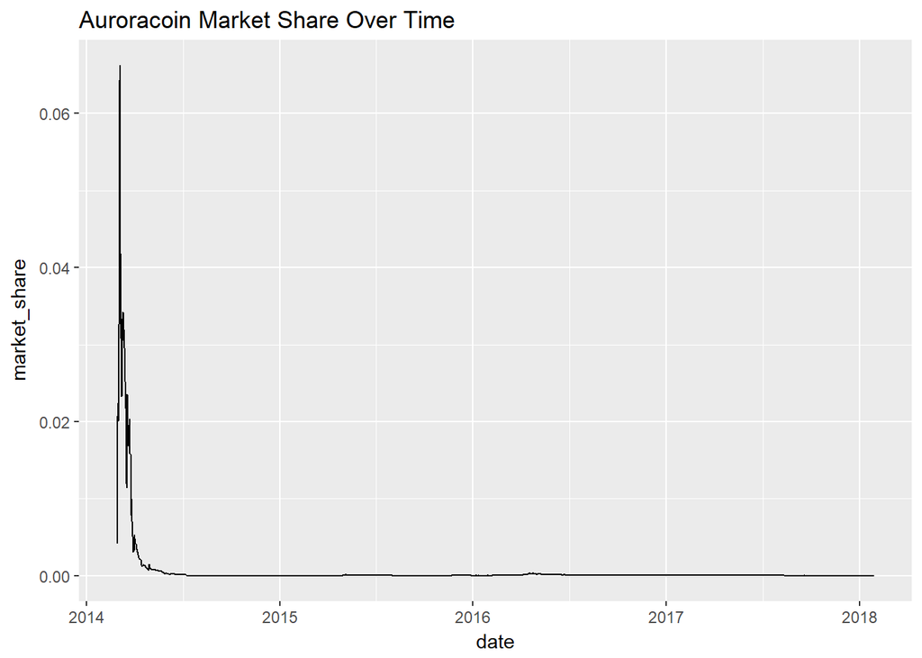

It looks like auroracoin achieved 6% market share in 2014 briefly before disappearing to irrelevance.

What about litecoin?

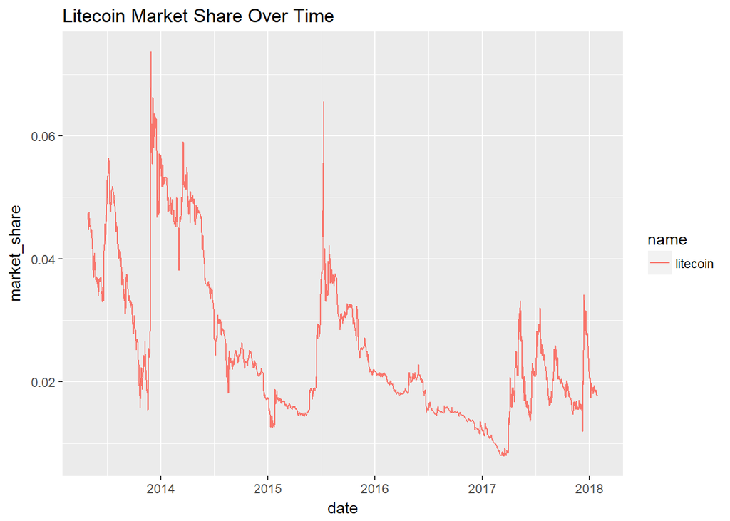

Today, the 3 largest players in the cryptocurrency market are Bitcoin, Ethereum and Ripple.

Below I plot their growth in market cap over time.

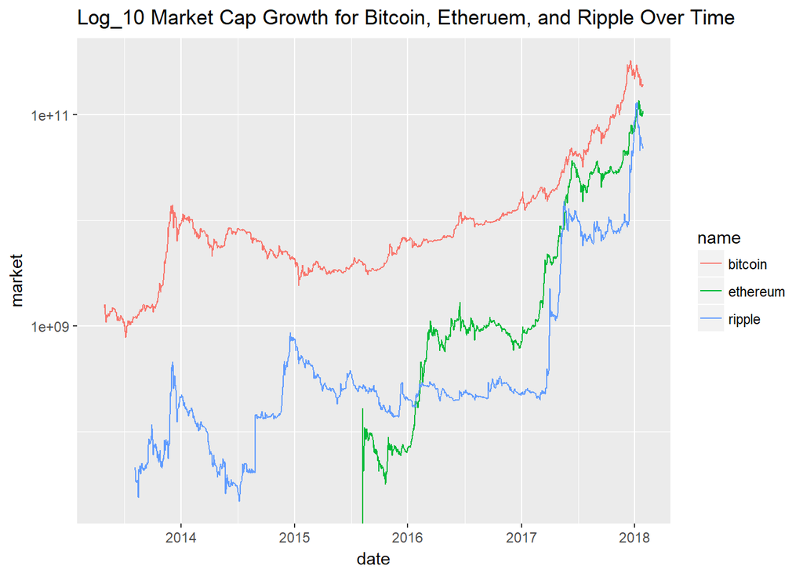

Exponential growth has been the norm for these 3 dominant tokens.

# Multivariate Analysis

### Talk about some of the relationships you observed in this part of the investigation. Were there features that strengthened each other in terms of looking at your feature(s) of interest?

Although the majority of cryptocurrencies went up in value in 2017. When we plot the gains side by side, even among highly correlated tokens with the highest market caps we can see that some increased much more than others.

Bitcoin has been the dominant cryptocurrency since inception. However, it’s interesting to note that Etheruem and Ripple gained tremendous marketshare in 2017.

### Were there any interesting or surprising interactions between features?

Bitcoin has been the dominant token over the years. However, it was also interesting to see that over the years there have been some tokens (like Auroracoin) that came, acquired some market share and then disappeared.

It was also interesting to see that tokens born in 2015 and 2016 perfomed better on the whole in 2017 than the other years. I wasn’t able to explain a reason for this.

# Final Plots and Summary

### Plot One - Growth

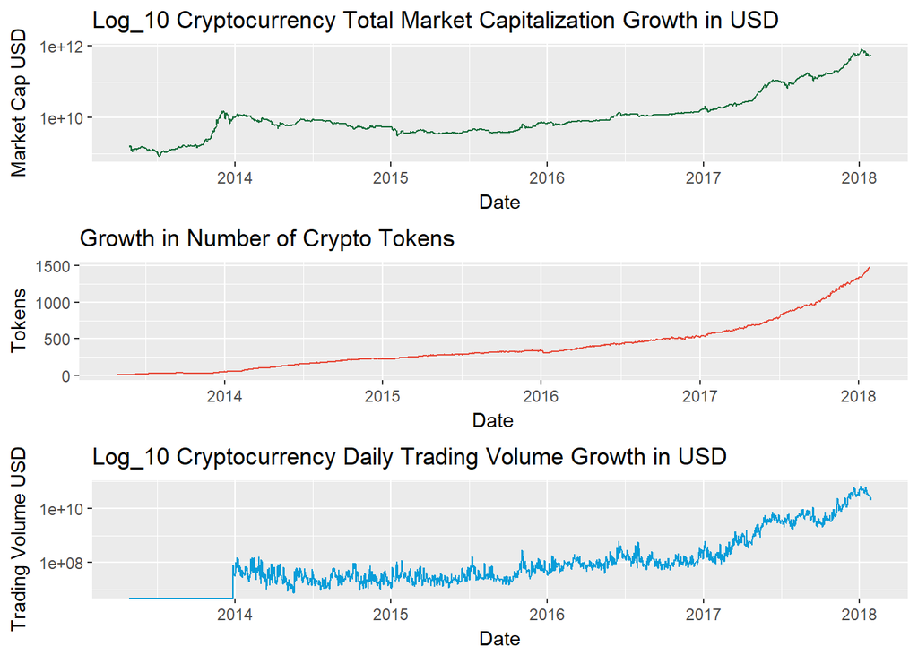

### Description One - Growth

The cryptocurrency market has grown exponentially since 2013.

The total cryptocurrency market capitalization has grown exponentially from $1.5 billion in 2013 to a peak of around $800 billion at the end of 2017.

In 2013 the number of tokens being tracked on coinmarketcap.com was 6. As of 28-Jan-2018 that number was 1494 and growing.

With larger marketcaps and more tokens the trading volume has grown exponentially as well. Trading volume has grown from around $100 million per day at the beginning of 2014 to an about of $25 billion per day around the end of 2017.

### Plot Two - The Dominant Crypto Tokens

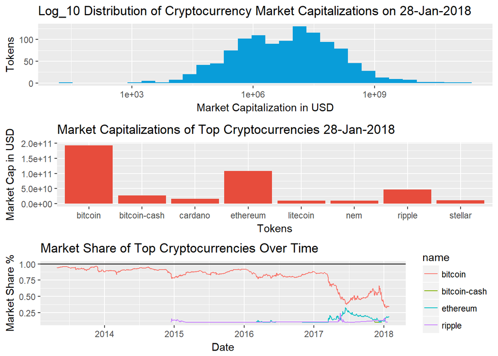

### Description Two - The Dominant Crypto Tokens

As of 28-Jan-2018, there were 1494 tokens being tracked on coinmarketcap.com.

However, the market capitalization among those tokens is logarithmically distributed. 50% of tokens have a market capitalization under $1.7 million and 90% of tokens have a market capitalization under $145 million.

The top 10% of tokens account for 96.9% of the total market, and the top 1% account for 83.1% of total market.

Even among the top 1% of tokens, Bitcoin, Ethereum, and Ripple are dominant.

Bitcoin has been the dominant crypto token since inception and has continued to hold market position even with 1494 coins. However, as we can see from the plot this has started to change in resent years. Ethereum and Ripple have been gaining marketshare in recent years and in 2017 Ethereum almost overtook bitcoin as the dominant token and newcomer Bitcoin Cash at one point had more than 10% Market Share.

### Plot Three - Uneven Gains

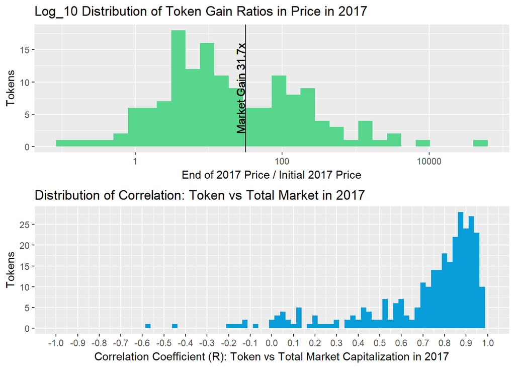

### Description Three - Uneven Gains

In 2017 the cryptocurrency market saw exponential growth. The total market capitalization grew 31.7x.

However, this growth wasn’t evenly distributed among tokens. Some tokens saw as much as 10,000 or 40,000x gains. However, the vast majority saw growth more inline with overall market growth. 50% of tokens grew 15.6x or less and 90% of tokens grew 379x or less.

Many coins are highly correlated with the overall market. However, many are not. The second graph shows the distribution of correlations between tokens and the overall market for 2017.

# Reflection

Reflecting on this data exploration.

The largest difficulties came as i tried to understand why some tokens change in price and market cap differed so greatly from that of other tokens.

Initially, in addition to exploring the data with plots and statistics I would have liked to create a model for predicting future market changes. As I dug deeper into the data I found it more and more difficult to think of a potential model to fit the data.

One reason for this is that the dataset was limited in that it only gave price and market capitalization information.

Ideally I would have information on the developer community building the crypto assets, the community surrounding the project, and information on public opinion of each coin as well. In that way I may be better able to predict market as well as individual token growth or decline over time.

For a future project I plan to scrap individual token data such as developer activity, community engagement, and public interest from a website like https://www.coingecko.com/en and use this data as part of a model for predicting future performance.

However, I believe I was successful in exploring the data I had. I learned a great deal about how the cryptocurrency market has evolved over the last 5 years. How it has grown in terms of capital, token quantity and trading volume. I got a nice, big picture view of the landscape as it stands today. And even though I don’t know why the performance of some tokens varied so much I was able to grasp the vast difference that exists among token performance and this has intrigued me to research more.